# lab4

celiaflorea

10/22/2020

#1 Estimate the letter occurrence probabilities of all 26 letters in English by measuring a paragraph of English text from wikipedia. (hint use strsplit() to split a paragraph into individual letters) (1 point).

```r
wikipedia <- "Pearson's tuco-tuco (Ctenomys pearsoni) is a species of rodent in the family Ctenomyidae.[2] It is endemic to Uruguay, where it is found at elevations below 200 m.[1] This tuco-tuco constructs burrows with multiple openings (an average of 13) containing one to two nests of dried grass; it prefers areas of sandy soil but is somewhat adaptable.[1] It is threatened by loss of habitat to development, agriculture and ranching.[1] Multiple karyotypes have been reported, including 2n = 68-70, FN = 80-88, as well as 2n = 56, FN = 77-79, suggesting the taxon may represent several species.[2] C. dorbignyi appears to be cytogenetically indistinguishable from the 2n = 70 form.[2] The species is named after American zoologist Oliver Payne Pearson.[3][4]"

wikipedia_letters <- unlist(strsplit(wikipedia, split = ""))
lower_case <- tolower(wikipedia_letters)
letter_counts<- table(lower_case)
letter_counts <- data.frame(letter_counts)

library(dplyr)
final <- letter_counts %>%
  filter(lower_case %in% letters == TRUE)

total_letters <-sum(final$Freq)

final <- final %>%
  mutate(probabilities = Freq/total_letters)

knitr::kable(final)
```

| lower_case | Freq | probabilities |
| --- | --- | --- |
| a | 43 | 0.0777577 |
| b | 10 | 0.0180832 |
| c | 20 | 0.0361664 |
| d | 16 | 0.0289331 |
| e | 67 | 0.1211573 |
| f | 13 | 0.0235081 |
| g | 15 | 0.0271248 |
| h | 13 | 0.0235081 |
| i | 44 | 0.0795660 |
| k | 1 | 0.0018083 |
| l | 21 | 0.0379747 |
| m | 14 | 0.0253165 |
| n | 43 | 0.0777577 |
| o | 43 | 0.0777577 |
| p | 18 | 0.0325497 |
| r | 32 | 0.0578662 |
| s | 45 | 0.0813743 |
| t | 49 | 0.0886076 |
| u | 18 | 0.0325497 |
| v | 6 | 0.0108499 |
| w | 7 | 0.0126582 |
| x | 1 | 0.0018083 |
| y | 13 | 0.0235081 |
| z | 1 | 0.0018083 |

#2 Generate “random” strings of letters that are sampled from a distribution where letter occurrence probability is the same as natural English. Use the probabilities for each letter from this wikipedia article, or use your own estimates from the previous question (2 points).

```r
my_letters <- sample(final$lower_case,50*5,replace=TRUE, prob = final$probabilities)

# turn the vector into a matrix with 5 columns
my_strings <- matrix(my_letters, ncol=5)

# each row is a word, need to collapse the column to create a string
paste(my_strings[1,], collapse="")
```

```
## [1] "aecui"
```

[output not shown]

```r
# loop to collapse all of the rows into words
random_strings <-c()
for(i in 1:dim(my_strings)[1]){
  random_strings[i] <- paste(my_strings[i,], collapse="")
}

random_strings
```

```
##  [1] "aecui" "nocdi" "nivio" "nuuua" "liiet" "eoton" "otlol" "awtpg" "lpnne"
## [10] "imbgs" "eubpe" "mtyns" "svgsi" "cossi" "obien" "epesm" "aboen" "eetns"
## [19] "sftsm" "yehnb" "wtpas" "nhdif" "oerma" "raeti" "rsane" "weoys" "fcdui"
## [28] "tnome" "cfgee" "xepeo" "stncs" "ireit" "sonir" "zfnso" "tahns" "potil"
## [37] "nirss" "ahenn" "sohdc" "pesbo" "yuabp" "hlsrt" "ollne" "panae" "tmeee"
## [46] "riiai" "esiyl" "lilsi" "idosm" "yrhey"
```

#3 Generate a random walk of 10,000 steps. In a random walk, you are simulating the process of randomly taking a step up or down, as if you are on an infinite staircase. At each step you flip a coin. If you get heads you go up one step, if you get tails you go down one step. Start on step 0, then simulate a random walk for 10,000 steps. Your vector should preserve the step number for each step. For example, if the the first three steps were all heads, then the vector would begin with 0,1,2,3, which indicates a single step up each time. Plot the first 1,000 steps. (1 point)

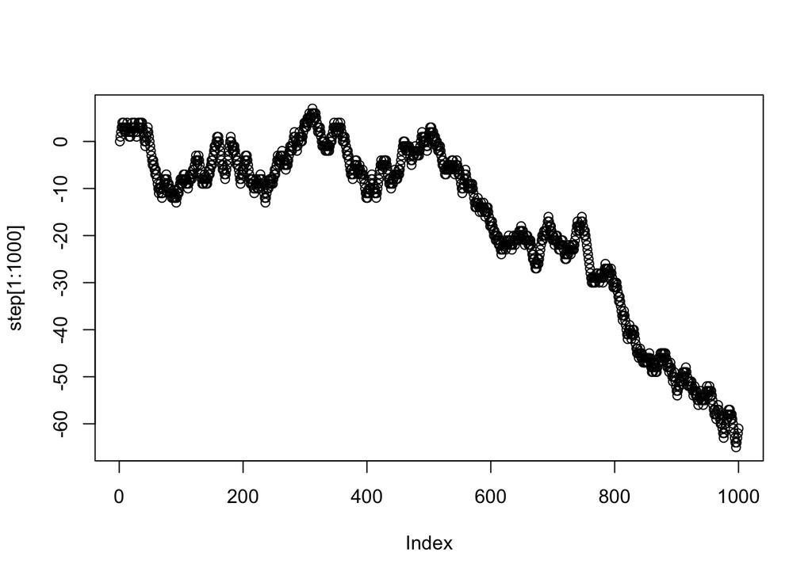

```r
step <- c(0)
for(i in 1:10000){
  coin_flip <- sample(c(1,-1), 1)
  step[i+1] <- step[i]+coin_flip
  }

plot(step[1:1000])
```

#4 What was the most positive and most negative step reached out of 10,000? (1 point)

```r
min(step)
```

```
## [1] -116
```

```r
max(step)
```

```
## [1] 52
```

#5 What was the longest run of steps where all steps were positive numbers. For example, in the sequence: 1,2,3,2,1,0,-1,-2,-1,-2,-1,0,1,2,3; the answer is 5 because the first five values were all positive, and this was the longest sequence of positive values. (1 point).

[output not shown]